# Clustering as a preprocessing step of scDesign2

Tianyi Sun

2021-06-22

# Introduction

The model fitting and data simulation of scDesign2 is performed for each cell type separately. Therefore, the partitioning of cell types, or cell clustering, is an important preprocessing step of scDesign2. The partitioning of cell types can be performed based on biological knowledge, e.g., marker genes, or using cell clustering algorithms, e.g., SC3 [1] or the Louvain method [2] as implemented in the Seurat package [3], or a combination of the two.

In this tutorial, we will use a subset of a real dataset to give a proof-of-concept demonstration of how cell clustering can be performed using the Louvain method from Seurat, and evaluated using ROGUE scores [4] and mLISI values [5]. Note that in real applications, the demonstrated procedure may not be an optimal way of clustering for every dataset, since prior biological knowledge is not incorporated. However, we believe that the following procedure will in general give a good enough clustering result for beginner users so that subsequently, the model fitting and data simulation of scDesign2 can be performed. For users with expertise in cell clustering or domain knowledge in biology, they can use their own cell clustering results before using scDesign2 to simulate data.

# Preparation

The dataset that we use is still the single cell RNA-seq (scRNA-seq) dataset that profiles the transcriptome of mouse small intestinal epithelium, with GEO number GSE92332. To simplify the analysis, we will select six cell types from the original dataset and only analyze this subset of the data.

```r
library(scDesign2)
RNGkind("L'Ecuyer-CMRG")

# preparation -----------------------------------------------------------------------------
data_filename <- "mouse_sie_10x.rds"
# select six cell types
cell_type_sel <- c("Stem", "Goblet", "Tuft", "TA.Early",
                   "Enterocyte.Progenitor", "Enterocyte.Progenitor.Early")
# shorten the cell type names, useful later when creating plots
cell_type_sel_short <- c("Stem", "Goblet", "Tuft", "TA.Early", "EP", "EP.Early")
platform <- "UMI"

# function of getting a submatrix of selected cell types ----------------------------------
get_submat <- function(data_mat, cell_type_sel){
  if(is.null(colnames(data_mat))){
    data_mat
  }else{
    data_mat[, colnames(data_mat) %in% cell_type_sel]
  }
}

# load real data, and get the submatrix of selected cell types (for illustration) ---------
data_mat <- readRDS(system.file("extdata", data_filename, package = "scDesign2"))

submat <- get_submat(data_mat, cell_type_sel)
```

The original dataset as well as the subset of the data both contain predefined cell type labels. For now, we will temporarily discard this information and perform clustering from scratch. In the end, we will compare the results based on the de novo clustering to the results based on the original cell type labels.

```r
# save the cell type information and then discard it from the data matrix
colnames_original <- colnames(submat)
colnames(submat) <- 1:ncol(submat)
```

# Clustering

To perform cell clustering, we use the Louvain method [2] as implemented in the Seurat R package [3]. In the following code, the function `get_cluster_seurat()` is based on [one of the tutorials](https://satijalab.org/seurat/articles/pbmc3k_tutorial.html) of the Seurat R package. Some of the key parameters are the number of “important” genes to include, the number of PCs to include, and the resolution of the clustering. Here, we use the default parameter values as given in the tutorial. (The installation instruction for Seurat can be found [here](https://satijalab.org/seurat/articles/install.html).)

To evaluate the quality of the clustering result, we use the ROGUE score, which is an entropy-based metric for assessing the purity of single cell populations [4]. The ROGUE score can be calculated for each cell cluster, and a higher value indicates higher level of homogeneity of the corresponding cluster. The ROGUE score calculation is wrapped up in the `check_cluster_quality()` function. (The installation instruction for ROGUE can be found [here](https://github.com/PaulingLiu/ROGUE#installation-guide).)

Another metric to evaluate the separation of cell clusters is the mcLISI value, which is proposed by the single-cell data integration method Harmony [5]. However, this value is computed only according to the 2D-visualization plot, and therefore is affected by the dimensionality reduction method. More about this will be discussed later in the visualization section. (The installation instruction for LISI can be found [here](https://github.com/immunogenomics/LISI).)

```r
# function of using ROGUE scores to check cluster qualities -------------------------------
library(tidyverse)
library(ROGUE)

check_cluster_quality <- function(data_mat, cell_type_sel,
                                  platform = c("full-length", "UMI")){
  platform <- match.arg(platform)

  data_mat_sel <- get_submat(data_mat, cell_type_sel)

  expr <- data_mat_sel
  rogue.res <- rogue(expr, labels = colnames(expr),
                     samples = rep(1, ncol(expr)), platform = platform)
  unlist(rogue.res)
}

# function of using Seurat to cluster -----------------------------------------------------
library(Seurat)

get_cluster_seurat <- function(data_mat, platform = c("full-length", "UMI"),
                               dims = 1:10, res = 0.5){
  platform <- match.arg(platform)
  submat <- data_mat

  if(is.null(rownames(submat)))
    rownames(submat) <- 1:nrow(submat)
  count_seurat <- CreateSeuratObject(counts = submat)
  ### normalization
  count_seurat <- NormalizeData(count_seurat)
  ### select highly variable genes
  count_seurat <- FindVariableFeatures(count_seurat, selection.method = "vst", nfeatures = 4000)
  ### scale the data
  count_seurat <- ScaleData(count_seurat)
  ### PCA
  count_seurat <- RunPCA(count_seurat,
                         features = VariableFeatures(object = count_seurat),
                         verbose = F)
  ### clustering
  count_seurat <- FindNeighbors(count_seurat, dims = dims)
  count_seurat <- FindClusters(count_seurat, resolution = res)
  ### results
  cluster_predicted <- as.integer(Idents(count_seurat))

  colnames(submat) <- as.character(cluster_predicted)
  rogue_scores <- check_cluster_quality(submat, unique(cluster_predicted), platform)
  list(clustering_result = cluster_predicted, rogue_scores = rogue_scores)
}
```

```r
# rogue score for real data with cluster label  -------------------------------------------
set.seed(1)
clustering_result <- get_cluster_seurat(submat, platform)

print(clustering_result$rogue_scores)
print(mean(clustering_result$rogue_scores))
```

```
#>         9        10         3         8         5         7         4         2
#> 0.6689216 0.7798399 0.8412682 0.9270943 0.6803729 0.7444940 0.8095958 0.7440954
#>         1         6
#> 0.9012378 0.8567513
#> [1] 0.7953671
```

From the above output, we can see that the Seurat clustering procedure gives 10 clusters, and the ROGUE score of each cluster ranges from 0.6689216 to 0.9270943, with an average of 0.7953671 across all clusters. Since the average is close to 0.8, this indicates a relatively good clustering quality.

For other datasets, if the average ROGUE score of the cell clusters is too low, parameter tuning of the clustering algorithm can be performed. For example, one can perform clustering based on a series of resolution values and choose the clustering result that gives the highest average ROGUE score across clusters. Besides the resolution, other parameters can also be tuned together.

# Model fitting and data simulation

Based on the above clustering result, we can now proceed to use scDesign2 to fit a model to each cell type and then simulate data accordingly. In the following code, the function `get_scDesign2_result()` wraps up these two steps.

```r
# use scDesign2 to fit model and simulate data with cluster label -------------------------
library(scDesign2)

get_scDesign2_result <- function(count_mat, cell_type_sel){
  submat <- get_submat(count_mat, cell_type_sel)
  n_cell_new <- ncol(submat)
  cell_type_prop <- table(colnames(submat))[cell_type_sel]
  copula_result <- fit_model_scDesign2(count_mat, cell_type_sel, sim_method = 'copula',
                                       ncores = length(cell_type_sel))
  sim_count_copula <- simulate_count_scDesign2(copula_result, n_cell_new, sim_method = 'copula',
                                               cell_type_prop = cell_type_prop)
  list(copula_result = copula_result, sim_count_copula = sim_count_copula)
}

set.seed(1)
colnames(submat) <- clustering_result$clustering_result
sim_count_cluster_label <- get_scDesign2_result(submat, unique(colnames(submat)))
saveRDS(sim_count_cluster_label, file = paste0("sim_count_cluster_label.rds"))
```

# t-SNE visualization

Finally, we visualize the results using t-SNE, a popular dimensionality reduction method for visualizing scRNA-seq data. We will visualize the real data and the simulated data separately and compare the patterns, and also combine them together to see whether they can mix well.

For quantitative evaluation, we will compute the mcLISI values for the real data and the simulated data, as well as the miLISI value for the combined data. The LISI, short for Local Inverse Simpson Index, is proposed in the Harmony paper [5]. The mcLISI is short for median cell-type LISI, which indicates the separation of cell types/clusters on the 2D visualization plot. The value is between 1 and 2, and a lower value indicates a better seapration of cell types/clusters. The miLISI is short for median integration LISI, which indicates the mixing of two datasets. It is also between 1 and 2, and a higher value indicates a better mixing of the two datasets.

```r
# use t-SNE to visualize the simulated data based on cluster label ------------------------
library(Rtsne)

### real data
set.seed(1)
tsne_result_real_data <- Rtsne(log(t(submat) + 1))

### cluster label
set.seed(1)
tsne_result_cluster_label <- Rtsne(log(t(sim_count_cluster_label$sim_count_copula)+1))
tsne_result_cluster_label_combined <-
  Rtsne(log(t(cbind(sim_count_cluster_label$sim_count_copula, submat)+1)))
```

```r
# plotting --------------------------------------------------------------------------------
library(ggplot2); theme_set(theme_bw());
library(RColorBrewer)
library(gridExtra)
library(plyr) # mapvalues
library(cowplot) # ggsave
library(ggpubr) # as_ggplot

### dat
dim_red_dat <- data.frame(
  rbind(tsne_result_real_data$Y, tsne_result_cluster_label$Y,
        tsne_result_cluster_label_combined$Y))
colnames(dim_red_dat) <- c('x', 'y')
dim_red_dat$labels <- c(clustering_result$clustering_result,
                       colnames(sim_count_cluster_label$sim_count_copula),
                       rep("simulated data", ncol(sim_count_cluster_label$sim_count_copula)),
                       rep("real data", ncol(submat)))
dim_red_dat$labels <- factor(dim_red_dat$labels,
                             levels = c(sort(unique(clustering_result$clustering_result)),
                                        "simulated data", "real data"))
dim_red_dat$panels <- c(rep("real data", ncol(submat)),
                        rep("simulated data", ncol(sim_count_cluster_label$sim_count_copula)),
                        rep("real data + simulated data",
                            ncol(submat) + ncol(sim_count_cluster_label$sim_count_copula)))
dim_red_dat$panels <- factor(dim_red_dat$panels,
                             levels = c("real data", "simulated data",
                                        "real data + simulated data"))

### lisi
library(lisi)
get_lisi <- function(x, subset_label){
  emb_dat <- subset(x, subset = panels == subset_label,
                    select = c("x", "y"))
  # str(emb_dat)
  emb_label <- subset(x, subset = panels == subset_label,
                      select = "labels", drop = FALSE)
  # str(emb_label)
  # str(compute_lisi(emb_dat, emb_label, "labels"))
  compute_lisi(emb_dat, emb_label, "labels")
}
subset_label_list <- c("real data", "simulated data", "real data + simulated data")
mlisi_tsne <- sapply(subset_label_list, function(subset_label){
  median(unlist(get_lisi(dim_red_dat, subset_label)))
})
print(mlisi_tsne)

dim_red_dat$panels <- mapvalues(dim_red_dat$panels, from = levels(dim_red_dat$panels),
                                to = c(paste0(levels(dim_red_dat$panels), "\n",
                                              c("[mcLISI = ", "[mcLISI = ", "[miLISI = "),
                                              format(round(mlisi_tsne, 3), nsmall = 3), "]")))
```

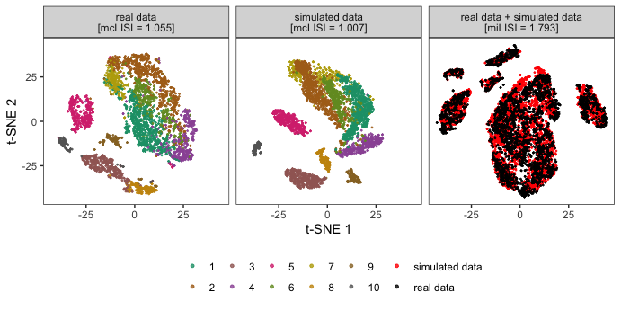

Figure 1: 2D t-SNE visualization of the real data, the simulated data, and the combined real data and simulated data, based on the Seurat clustering procedure.

```r
### plotting
point_size <- 0.25; point_transp <- 0.8

get_colScale <- function(labels){
  cbPalette <- c("#999999", "#E69F00", "#56B4E9", "#009E73",
                 "#F0E442", "#0072B2", "#D55E00", "#CC79A7")
  n_cell_type <- length(levels(labels)) - 2
  # print(str(labels))
  if(n_cell_type > 8)
  {
    colourCount <- n_cell_type
    getPalette <- colorRampPalette(brewer.pal(8, "Dark2"))
    cbPalette <- getPalette(colourCount)
  }else{
    cbPalette <- cbPalette[1:n_cell_type]
  }
  cbPalette <- c(cbPalette, '#FF0000', '#000000')
  names(cbPalette) <- levels(labels)
  scale_colour_manual(name = "labels",values = cbPalette)
}

dim_red_plot1 <- ggplot(dim_red_dat, aes(x = x, y = y, color = labels)) +
  geom_point(cex = point_size, alpha = point_transp) +
  facet_wrap(~panels, nrow = 1) +
  theme(plot.title = element_text(hjust = 0.5),
        panel.grid.major = element_blank(),
        panel.grid.minor = element_blank(),
        legend.position = "bottom",
        legend.title = element_blank()) +
  guides(color=guide_legend(override.aes = list(size = 1),
                            nrow=2, byrow=FALSE)) +
  get_colScale(dim_red_dat$labels) +
  xlab("t-SNE 1") + ylab("t-SNE 2")

print(dim_red_plot1)
```

From the first two panels of Figure 1 above, we can see that the t-SNE patterns of the real data and the simulated data are very similar. From the third panel of Figure 1, we can see that the simulated data can mix well with the real data. These results confirm that the model fitting and data simulation of scDesign2 is successful and moreover that the clustering performed using the Seurat procedure has done a good job in partitioning the cells.

# Comparison to the results based on the original cell type labels

Now, we will compare the model fitting and data simulation results based on the original cell type labels. The analysis pipeline is similar as above, which is (1) calculating ROGUE scores for each cell type/cluster, (2) fit model and simulate data for each cell type/cluster using scDesign2, and (3) visualize the results using t-SNE.

```r
# clustering and ROGUE scores ------------------------------------------------------------
### original label
rogue_scores_original <- check_cluster_quality(submat, cell_type_sel, platform)

print(rogue_scores_original)
print(mean(rogue_scores_original))
```

```
#>                        Tuft                      Goblet
#>                   0.5992410                   0.5771344
#>                        Stem                    TA.Early
#>                   0.6457390                   0.6794770
#> Enterocyte.Progenitor.Early       Enterocyte.Progenitor
#>                   0.6322831                   0.6747741
#> [1] 0.6347747
```

From the above results, we can see that there are six cell types in the dataset of interest, and compared to the cell clustering results before, the ROGUE scores of these six cell types are relatively low, with an average of only 0.6347747.

```r
# Compare to the ROGUE score based on the Seurat clustering procedure
print(clustering_result$rogue_scores)
print(mean(clustering_result$rogue_scores))
```

```
#>         9        10         3         8         5         7         4         2
#> 0.6689216 0.7798399 0.8412682 0.9270943 0.6803729 0.7444940 0.8095958 0.7440954
#>         1         6
#> 0.9012378 0.8567513
#> [1] 0.7953671
```

This suggests that when the model fitting and data simulation is performed based on these original cell type labels, the simulated data may be less similar to the real data. We will proceed to see whether this is true.

```r
# use scDesign2 to fit model and simulate data with original label ------------------------
set.seed(1)
colnames(submat) <- colnames_original

sim_count_original_label <- get_scDesign2_result(submat, cell_type_sel)

saveRDS(sim_count_original_label, file = paste0("sim_count_original_label.rds"))

# use t-SNE to visualize the simulated data based on original label -----------------------
### original label
sim_count_original_label <-
  readRDS(file = paste0("sim_count_original_label.rds"))

set.seed(1)
tsne_result_original_label <- Rtsne(log(t(sim_count_original_label$sim_count_copula)+1))
tsne_result_original_label_combined <-
  Rtsne(log(t(cbind(sim_count_original_label$sim_count_copula, submat)+1)))
```

```r
# plotting for data of original labels -----------------------------------------------------
### dat
dim_red_dat <- data.frame(
  rbind(tsne_result_real_data$Y, tsne_result_original_label$Y,
        tsne_result_original_label_combined$Y))
colnames(dim_red_dat) <- c('x', 'y')
dim_red_dat$labels <- c(colnames_original,
                        colnames(sim_count_original_label$sim_count_copula),
                        rep("simulated data", ncol(sim_count_original_label$sim_count_copula)),
                        rep("real data", ncol(submat)))
dim_red_dat$labels <- factor(dim_red_dat$labels,
                             levels = c(cell_type_sel,
                                        "simulated data", "real data"))
dim_red_dat$labels <- mapvalues(dim_red_dat$labels, from = levels(dim_red_dat$labels),
                                to = c(cell_type_sel_short, 'simulated data', 'real data'))
dim_red_dat$panels <- c(rep("real data", ncol(submat)),
                        rep("simulated data", ncol(sim_count_original_label$sim_count_copula)),
                        rep("real data + simulated data",
                            ncol(submat) + ncol(sim_count_original_label$sim_count_copula)))
dim_red_dat$panels <- factor(dim_red_dat$panels,
                             levels = c("real data", "simulated data",
                                        "real data + simulated data"))

### lisi
subset_label_list <- c("real data", "simulated data", "real data + simulated data")
mlisi_tsne <- sapply(subset_label_list, function(subset_label){
  median(unlist(get_lisi(dim_red_dat, subset_label)))
})
print(mlisi_tsne)

dim_red_dat$panels <- mapvalues(dim_red_dat$panels, from = levels(dim_red_dat$panels),
                                to = c(paste0(levels(dim_red_dat$panels), "\n",
                                              c("[mcLISI = ", "[mcLISI = ", "[miLISI = "),
                                              format(round(mlisi_tsne, 3), nsmall = 3), "]")))
```

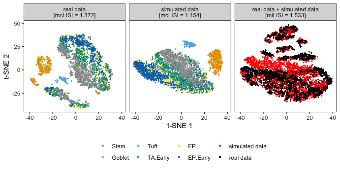

Figure 2: 2D t-SNE visualization of the real data, the simulated data, and the combined real data and simulated data, based on the original cell type labels.

```r
### plotting
dim_red_plot2 <- ggplot(dim_red_dat, aes(x = x, y = y, color = labels)) +
  geom_point(cex = point_size, alpha = point_transp) +
  facet_wrap(~panels, nrow = 1) +
  theme(plot.title = element_text(hjust = 0.5),
        panel.grid.major = element_blank(),
        panel.grid.minor = element_blank(),
        legend.position = "bottom",
        legend.title = element_blank()) +
  guides(color=guide_legend(override.aes = list(size = 1),
                            nrow=2, byrow=FALSE)) +
  get_colScale(dim_red_dat$labels) +
  xlab("t-SNE 1") + ylab("t-SNE 2")

print(dim_red_plot2)
```

Indeed, in Figure 2 above, the pattern of the simulated data is less similar to the real data than in Figure 1, and they also do not mix as well, as indicated by the many non-overlapping red points as well as a lower miLISI value.

# Summary

In this tutorial, we have demonstrated how to use the Seurat clustering procedure to cluster cells in order for the model fitting and data simulation of scDesign2 to be performed. We have also shown that the ROGUE score can be used to evaluate the quality of the clustering and help with improving the clustering result. Finally, t-SNE visualization and mLISI values can be used to evaluate the resemblence of the simulated data and the real data.

# References

[1] V. Y. Kiselev *et al.*, “SC3: Consensus clustering of single-cell RNA-seq data,” *Nature Methods*, vol. 14, no. 5, pp. 483–486, Mar. 2017, doi: 10.1038/nmeth.4236.

[2] V. D. Blondel, J.-L. Guillaume, R. Lambiotte, and E. Lefebvre, “Fast unfolding of communities in large networks,” *Journal of Statistical Mechanics: Theory and Experiment*, vol. 2008, no. 10, Oct. 2008, doi: 10.1088/1742-5468/2008/10/p10008.

[3] T. Stuart *et al.*, “Comprehensive integration of single-cell data,” *Cell*, vol. 177, pp. 1888–1902, 2019, doi: 10.1016/j.cell.2019.05.031.

[4] B. Liu, C. Li, Z. Li, D. Wang, X. Ren, and Z. Zhang, “An entropy-based metric for assessing the purity of single cell populations,” *Nature communications*, vol. 11, no. 1, pp. 1–13, 2020, doi: 10.1038/s41467-020-16904-3.

[5] I. Korsunsky *et al.*, “Fast, sensitive and accurate integration of single-cell data with Harmony,” *Nature methods*, vol. 16, no. 12, pp. 1289–1296, 2019, doi: 10.1038/s41592-019-0619-0.

[6] T. Sun, D. Song, W. V. Li, and J. J. Li, “scDesign2: A transparent simulator that generates high-fidelity single-cell gene expression count data with gene correlations captured,” *Genome biology*, vol. 22, no. 1, pp. 1–37, 2021, doi: 10.1186/s13059-021-02367-2.